# Getting Started with the Communities Package

Fabio Morea

2025-09-29

## Introduction

The `communities` package addresses fundamental reproducibility issues in network community detection by providing a comprehensive framework for solution space exploration. Rather than accepting a single algorithm run, this package systematically explores the complete solution space through controlled randomization and Bayesian modeling.

### The Problem with Traditional Community Detection

Traditional community detection workflows suffer from three critical issues:

1. **Solution multiplicity**: Many networks admit multiple valid community structures
2. **Input ordering bias**: Results depend on arbitrary node/edge processing order
3. **Outlier handling**: Nodes that don’t clearly belong to any community are poorly managed

This package provides principled solutions to all three problems.

## Core Concepts

### Solution Space Exploration

Instead of running a community detection algorithm once, we run it multiple times with systematic vertex permutation. This reveals the full solution space and quantifies the stability of different partitions.

### Bayesian Framework

Solution probabilities are modeled using a Dirichlet-Multinomial framework with Beta credible intervals, providing principled uncertainty quantification and convergence assessment.

### Solution Space Taxonomy

Results are classified into five interpretable categories: - **Single**: One stable solution - **Dominant**: One solution clearly separated from alternatives - **Multiple**: Several solutions with comparable probabilities - **Sparse**: Many low-probability solutions (often indicating instability) - **Empty**: No valid community structure detected

## Basic Workflow

### Step 1: Create or Load a Network

Let’s start with a simple example using a ring of cliques network:

```r
# Create a ring of cliques with known community structure
set.seed(42)
graph <- make_ring_of_cliques(n_cliques = 4,
                              clique_size = 6,
                              variant = "RC+C")

# Basic network properties
cat("Network properties:\n")
```

```
#> Network properties:
```

```r
cat("Vertices:", vcount(graph), "\n")
```

```
#> Vertices: 25
```

```r
cat("Edges:", ecount(graph), "\n")
```

```
#> Edges: 68
```

```r
cat("Ground truth communities:", max(V(graph)$gt_community), "\n")
```

```
#> Ground truth communities: 4
```

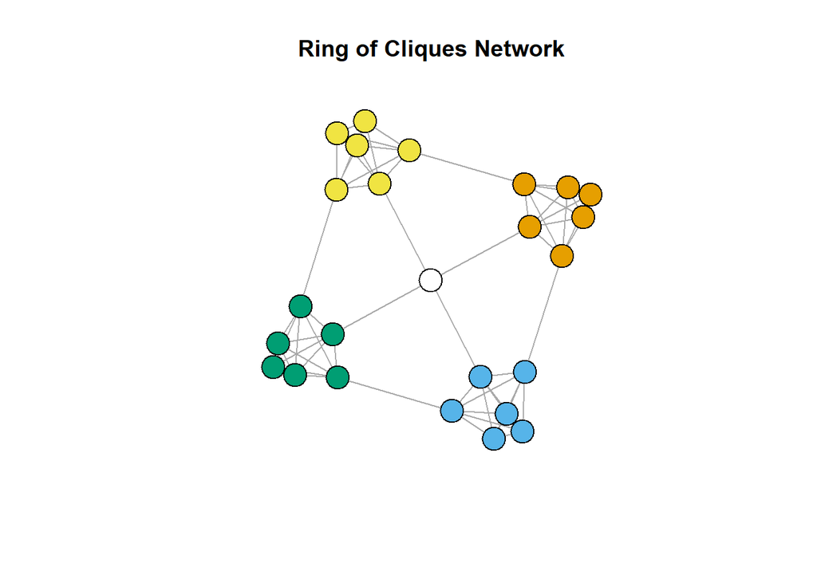

```r
# Visualize the network
plot(graph,
     vertex.color = V(graph)$gt_community,
     vertex.size = 15,
     vertex.label = NA,
     main = "Ring of Cliques Network")
```

### Step 2: Explore the Solution Space

```r
# Explore solution space with systematic vertex permutation
solution_space_result <- solutions_space_DM(
  graph = graph,
  n_trials = 200,            # Number of algorithm trials
  method = "LV",             # algorithm
  precision_threshold = 0.1, # Convergence threshold
  random_seed = 123         # For reproducibility
)

# View the discovered solutions
knitr::kable(solution_space_result$probabilities,
             digits = 3,
             caption = "Solution Space Results")
```

Solution Space Results

|  | id | count | phat | pmin | pmax |
| --- | --- | --- | --- | --- | --- |
| 2 | s02 | 61 | 0.304 | 0.243 | 0.369 |
| 1 | s01 | 48 | 0.240 | 0.184 | 0.301 |
| 4 | s04 | 46 | 0.230 | 0.175 | 0.290 |
| 3 | s03 | 45 | 0.225 | 0.171 | 0.285 |

### Step 3: Classify the Solution Space

Determine what type of solution space we discovered:

```r
# Classify the solution space type
space_type <- communities::solution_space_type(solution_space_result)
cat("Solution space type:", space_type, "\n")
```

```
#> Solution space type: Multiple
```

```r
# Examine convergence
cat("Convergence details:\n")
```

```
#> Convergence details:
```

```r
cat("- Stopped at trial:", solution_space_result$log$stop_trial, "\n")
```

```
#> - Stopped at trial: 200
```

```r
cat("- Reason:", solution_space_result$log$stop_reason, "\n")
```

```
#> - Reason: trial_budget_exhausted
```

```r
cat("- Final CI width:", tail(solution_space_result$log$max_ci_width, 1), "\n")
```

```
#> - Final CI width: 0.1257545
```

### Step 4: Quality Assessment

Assess the quality of discovered solutions:

```r
# Comprehensive quality assessment
quality_results <- quality_check(graph, solution_space_result)

# Provide interpretive summary
cat("Quality Assessment Summary:\n")
```

```
#> Quality Assessment Summary:
```

```r
cat("========================\n")
cat("Total solutions found:", nrow(quality_results), "\n")
```

```
#> Total solutions found: 4
```

```r
cat("Valid solutions:", sum(quality_results$valid, na.rm = TRUE), "\n")
```

```
#> Valid solutions: 4
```

```r
cat("Invalid solutions:", sum(!quality_results$valid, na.rm = TRUE), "\n")
```

```
#> Invalid solutions: 0
```

```r
if (any(!quality_results$valid)) {
  cat("\nReasons for invalidity:\n")
  invalid_reasons <- quality_results$reason[!quality_results$valid]
  invalid_reasons <- invalid_reasons[invalid_reasons != ""]
  if (length(invalid_reasons) > 0) {
    for (reason in unique(invalid_reasons)) {
      count <- sum(invalid_reasons == reason)
      cat("-", reason, "(", count, "solutions )\n")
    }
  }
}

# Highlight best solutions
if (any(quality_results$valid)) {
  best_solutions <- quality_results[quality_results$valid, ]
  best_solutions <- best_solutions[order(best_solutions$modularity, decreasing = TRUE), ]

  cat("\nTop valid solutions by modularity:\n")
  top_3 <- head(best_solutions, 3)
  for (i in 1:nrow(top_3)) {
    cat(sprintf("Solution %d: Modularity=%.3f, Communities=%d, μ=%.3f\n",
                top_3$solution_id[i], top_3$modularity[i],
                top_3$k[i], top_3$mu[i]))
  }
}
```

```
#>
#> Top valid solutions by modularity:
#> Solution 1: Modularity=0.646, Communities=4, μ=0.103
#> Solution 2: Modularity=0.646, Communities=4, μ=0.103
#> Solution 3: Modularity=0.646, Communities=4, μ=0.103
```

## Advanced Analysis

### Building Consensus Communities

When multiple solutions exist, we can build consensus communities:

```r
# Build co-occurrence matrix
co_occurrence_matrix <- co_occurrence(solution_space_result)

# Find consensus communities
consensus_result <- consensus_communities(
  co_occurrence_matrix = co_occurrence_matrix,
  co_occurrence_threshold = 0.5,
  group_outliers = FALSE
)

# Summarize consensus results
consensus_summary <- consensus_result %>%
  group_by(consensus_community_label) %>%
  summarise(
    community_size = n(),
    avg_confidence = mean(uncertainty_coefficient, na.rm = TRUE),
    .groups = "drop"
  ) %>%
  arrange(desc(community_size))

knitr::kable(consensus_summary,
             digits = 3,
             caption = "Consensus Communities Summary")
```

Consensus Communities Summary

| consensus_community_label | community_size | avg_confidence |
| --- | --- | --- |
| 1 | 6 | 0.099 |
| 2 | 6 | 0.110 |
| 3 | 6 | 0.109 |
| 4 | 6 | 0.111 |
| 5 | 1 | 0.720 |

### Outlier Detection

Identify nodes with uncertain community membership:

```r
# Identify potential outliers based on uncertainty
outlier_candidates <- consensus_result %>%
  filter(uncertainty_coefficient > 0.3) %>%  # High uncertainty threshold
  arrange(desc(uncertainty_coefficient))

if (nrow(outlier_candidates) > 0) {
  knitr::kable(outlier_candidates,
               digits = 3,
               caption = "Potential Outlier Nodes")
} else {
  cat("No outliers detected with uncertainty > 0.3\n")
}
```

Potential Outlier Nodes

| node_name | consensus_community_label | uncertainty_coefficient | community_size | is_singleton |
| --- | --- | --- | --- | --- |
| center | 5 | 0.72 | 1 | TRUE |

## Visualization

### Solution Space Evolution

Track how solution probabilities evolve during exploration:

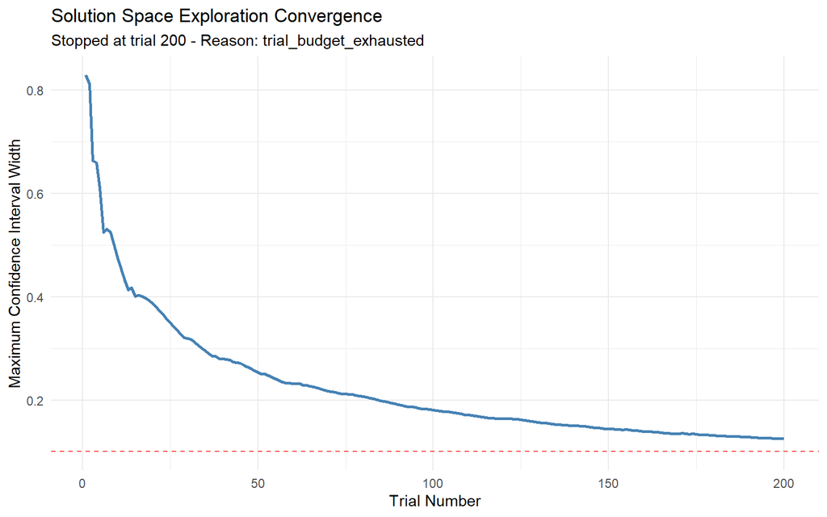

```r
# Plot convergence of credible interval widths instead
convergence_data <- data.frame(
  trial = 1:solution_space_result$log$stop_trial,
  ci_width = solution_space_result$log$max_ci_width
)

ggplot(convergence_data, aes(x = trial, y = ci_width)) +
  geom_line(color = "steelblue", size = 1) +
  geom_hline(yintercept = solution_space_result$log$precision_threshold,
             color = "red", linetype = "dashed", alpha = 0.7) +
  labs(title = "Solution Space Exploration Convergence",
       subtitle = paste("Stopped at trial", solution_space_result$log$stop_trial,
                        "- Reason:", solution_space_result$log$stop_reason),
       x = "Trial Number",
       y = "Maximum Confidence Interval Width") +
  theme_minimal()
```

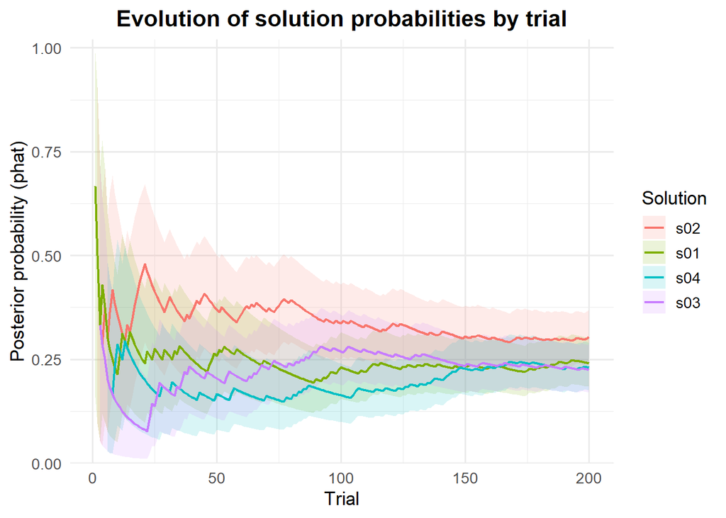

```r
communities::plot_sol_space_evolution(solution_space_result)
```

### Solution Comparison

Compare the different solutions found:

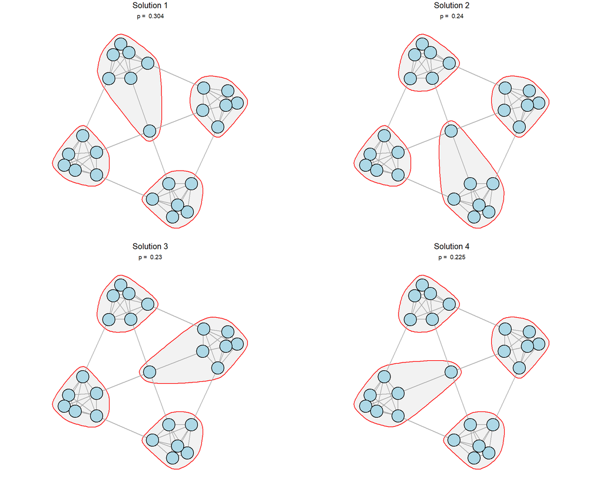

```r
# Plot all solutions found
plot_solutions(
  graph,
  solution_space_result,
  add_node_labels = FALSE,
  add_prob_labels = TRUE,
  add_title = TRUE
)
```

## Comparing Different Algorithms

Let’s compare how different algorithms behave on the same network:

```r
# Compare multiple algorithms
algorithms <- c("IM", "LV", "LD", "WT")
algorithm_results <- list()

for (alg in algorithms) {
  cat("Running", alg, "algorithm...\n")
  algorithm_results[[alg]] <- solutions_space_DM(
    graph = graph,
    n_trials = 30,  # Fewer trials for comparison
    method = alg,
    precision_threshold = 0.15,
    verbose = FALSE,
    random_seed = 123
  )
}
```

```
#> Running IM algorithm...
#> Running LV algorithm...
#> Running LD algorithm...
#> Running WT algorithm...
```

```r
# Compare solution space types
comparison_summary <- data.frame(
  Algorithm = algorithms,
  Solution_Space_Type = sapply(algorithm_results, solution_space_type),
  N_Solutions = sapply(algorithm_results, function(x) ncol(x$partitions)),
  N_Trials = sapply(algorithm_results, function(x) x$log$stop_trial),
  Converged = sapply(algorithm_results, function(x) x$log$stop_reason == "precision_achieved")
)

knitr::kable(comparison_summary,
             caption = "Algorithm Comparison Results")
```

Algorithm Comparison Results

|  | Algorithm | Solution_Space_Type | N_Solutions | N_Trials | Converged |
| --- | --- | --- | --- | --- | --- |
| IM | IM | Single | 1 | 22 | TRUE |
| LV | LV | Multiple | 4 | 30 | FALSE |
| LD | LD | Empty | 18 | 18 | TRUE |
| WT | WT | Multiple | 4 | 30 | FALSE |

## Real-World Example: Karate Club Network

Let’s apply the framework to a classic network dataset:

```r
# Load the classic karate club network
karate_graph <- make_graph("Zachary")

# Add edge weights (all equal for this example)
E(karate_graph)$weight <- 1

# Explore solution space
karate_solution_space <- solutions_space_DM(
  graph = karate_graph,
  n_trials = 100,
  method = "LV",  # Louvain algorithm
  precision_threshold = 0.1,
  verbose = FALSE,
  random_seed = 456
)

# Results summary
cat("Karate Club Network Analysis:\n")
```

```
#> Karate Club Network Analysis:
```

```r
cat("Solution space type:", solution_space_type(karate_solution_space), "\n")
```

```
#> Solution space type: Multiple
```

```r
cat("Number of solutions found:", ncol(karate_solution_space$partitions), "\n")
```

```
#> Number of solutions found: 8
```

```r
# Show solution probabilities
karate_solution_space$probabilities
```

|  | id | count | phat | pmin | pmax |
| --- | --- | --- | --- | --- | --- |
| 3 | s03 | 28 | 0.26851852 | 0.189615178 | 0.35553988 |
| 4 | s04 | 24 | 0.23148148 | 0.157266869 | 0.31510954 |
| 2 | s02 | 22 | 0.21296296 | 0.141408788 | 0.29457737 |
| 5 | s05 | 19 | 0.18518519 | 0.118073072 | 0.26332601 |
| 6 | s06 | 4 | 0.04629630 | 0.015344611 | 0.09295471 |
| 1 | s01 | 1 | 0.01851852 | 0.002271708 | 0.05097254 |
| 7 | s07 | 1 | 0.01851852 | 0.002271708 | 0.05097254 |
| 8 | s08 | 1 | 0.01851852 | 0.002271708 | 0.05097254 |

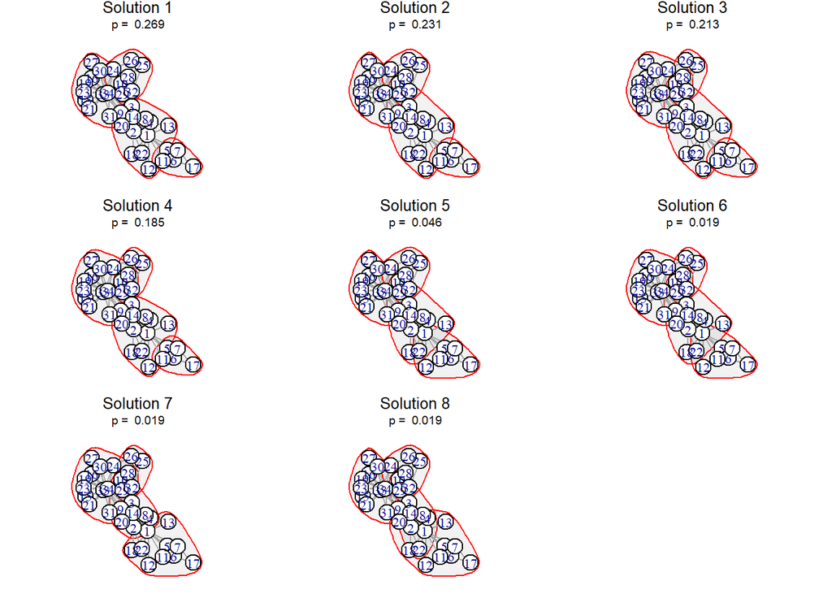

```r
communities::plot_solutions(karate_graph,karate_solution_space)
```

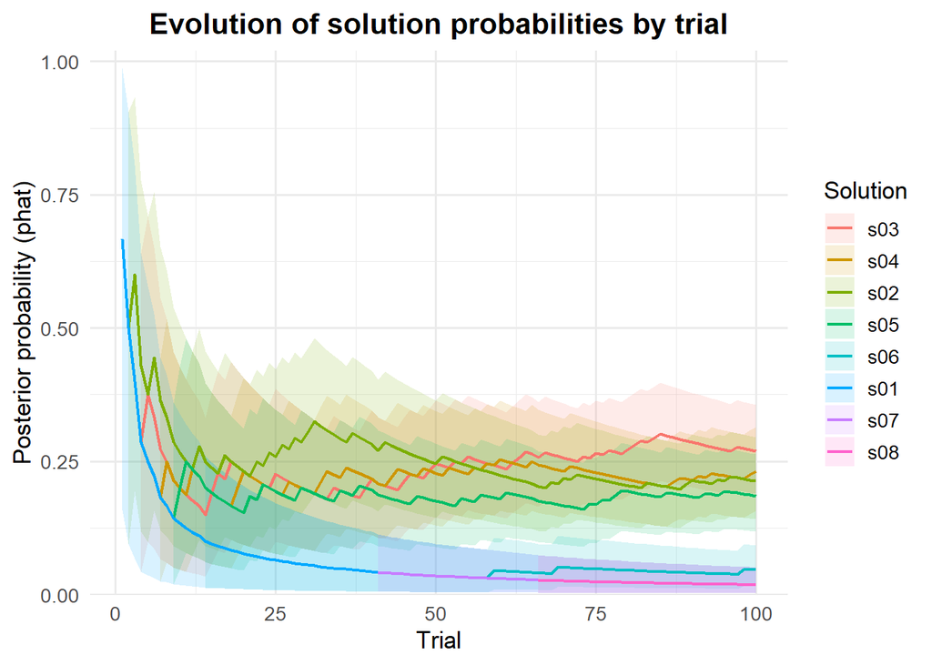

```r
communities::plot_sol_space_evolution(karate_solution_space)
```

## Best Practices

### 1. Parameter Selection

**Number of trials**: Start with 50-100 trials. Increase if you get “Sparse” solution spaces.

**Precision threshold**: Use 0.05 for exploratory analysis, 0.02 for publication-quality results.

**Algorithm choice**: - **Infomap (IM)**: Good general-purpose algorithm - **Louvain (LV)**: Fast, good for large networks - **Leiden (LD)**: Improved version of Louvain - **Walktrap (WT)**: Based on random walks

### 2. Interpreting Results

**Single solution space**: Safe to report the unique solution.

**Dominant solution space**: Report the dominant solution but acknowledge alternatives exist.

**Multiple solution space**: Consider consensus communities or report the uncertainty.

**Sparse solution space**: May indicate lack of clear community structure.

### 3. Quality Assessment

Always check solution quality:

- Modularity should be positive (preferably > 0.3)
- Mixing parameter should be < 0.5
- Communities should be internally connected

### 4. Reproducibility

Always set a random seed for reproducible results:

```r
# Example of reproducible analysis
set.seed(789)
result1 <- solutions_space_DM(graph, n_trials = 20, method = "IM", verbose = FALSE)

set.seed(789)  # Same seed
result2 <- solutions_space_DM(graph, n_trials = 20, method = "IM", verbose = FALSE)

# Results should be identical
identical(result1$probabilities, result2$probabilities)
```

```
#> [1] TRUE
```

## Common Issues and Solutions

### Issue 1: “Sparse” Solution Spaces

**Problem**: Algorithm finds many different solutions with low probabilities.

**Solutions**: - Increase number of trials - Try a different algorithm - Check if the network actually has clear community structure - Consider that the network may be inherently ambiguous

### Issue 2: All Solutions Invalid

**Problem**: Quality assessment marks all solutions as invalid.

**Solutions**: - Relax quality thresholds (e.g., increase `mu_threshold`) - Check if the network has meaningful community structure - Examine the mixing parameter - values > 0.5 suggest weak communities

## Summary

The `communities` package provides a principled approach to community detection that addresses fundamental reproducibility issues. Key benefits:

1. **Systematic exploration**: Reveals the complete solution space rather than a single result
2. **Uncertainty quantification**: Provides confidence measures for community assignments
3. **Bias mitigation**: Addresses input ordering bias through controlled randomization
4. **Quality assessment**: Comprehensive evaluation of solution validity
5. **Consensus building**: Methods to synthesize information across multiple solutions

This framework is particularly valuable for:

- Research requiring reproducible results
- Networks with ambiguous community structure
- Comparative studies of community detection algorithms
- Applications where uncertainty quantification is important

## Further Reading

For more details on the theoretical foundation, see:

Morea, F. and De Stefano, D. (2024). “A Comprehensive Framework for Solution Space Exploration in Community Detection.” *Under Review*.